# BSBMSE: Management Strategy Evaluation for California Barred Sand Bass

## 7.2 Closed-Loop Simulation Testing of MPs

Now that we have a basic check of MP function we can evaluate options in closed loop:

```r
# Default vs 1 fish Bag Limit vs weird slot limit
om_s=Subset(om, Sims = 1:8)
hist_s = Simulate(om_s)
proj = Project(hist_s, c("IR_BSB","BLtest","SLtest"))


# Alternative bag limits
BL1 = BL2 = BL3 = BL4 = BL5 = BL6 = IR_BSB
formals(BL1)$BL = c(NA, 1, NA, 1, NA, NA)
formals(BL2)$BL = c(NA, 2, NA, 2, NA, NA)
formals(BL3)$BL = c(NA, 3, NA, 3, NA, NA)
formals(BL4)$BL = c(NA, 4, NA, 4, NA, NA)
formals(BL5)$BL = c(NA, 5, NA, 5, NA, NA)
formals(BL6)$BL = c(NA, 6, NA, 6, NA, NA)
class(BL1) = class(BL2) = class(BL3) = class(BL4) = class(BL5) = class(BL6) = 'mp'
projBL = Project(hist_s, paste0("BL",1:6))
```

We can now plot the results.

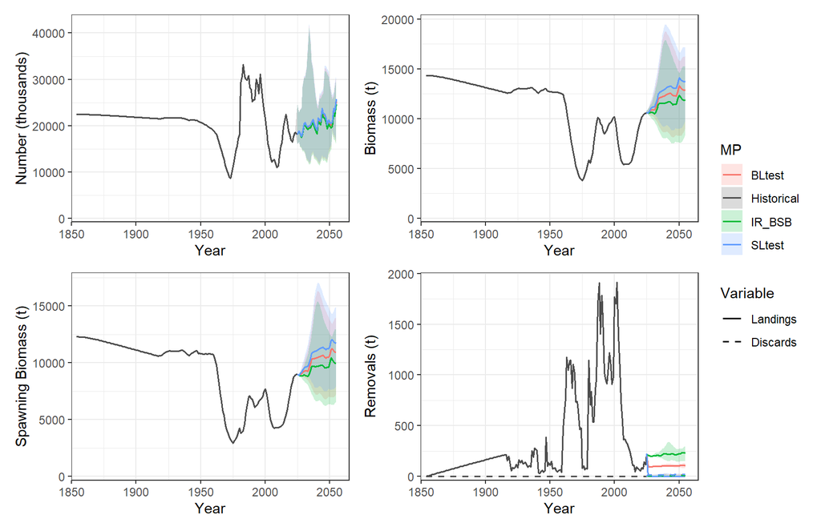

```r
plot(proj)
```

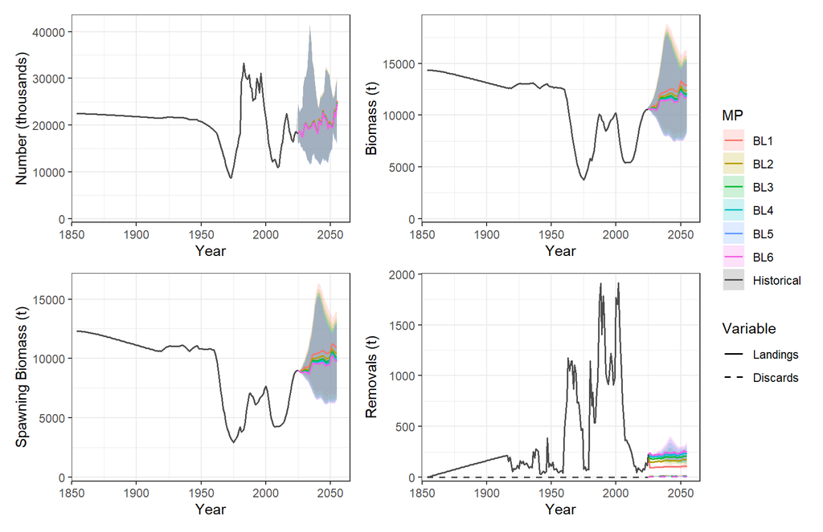

```r
plot(projBL)
```

Even though these results are preliminary, early indications are that very large changes in bag limit regulations e.g. 6-3 have a relatively small impact on both catches and biomass outcomes.

# 8 Outstanding tasks:

These could include:

- Performance metrics summary
- Alternative SS3 Assessments as OMs
- Detailed bag-limits vs size limit analysis

# 9 Acknowledgements

BSBMSE is funded by:

Fathom Consulting

And developed in collaboration with

The California Department of Fish and Wildlife:

Julia Coates, Allison Dedrick and Laura Ryley